# Impact due to Sever Weather Events

Hector Hernandez

October 25, 2016

# Public economic and healh affectation in the U.S. by Sever Weather

## Synopsis

Storms and other severe weather events can cause both public health and economic problems for communities and municipalities. Many severe events can result in fatalities, injuries, and property damage, and preventing such outcomes to the extent possible is a key concern.

This project involves exploring the U.S. National Oceanic and Atmospheric Administration’s (NOAA) storm database. This database tracks characteristics of major storms and weather events in the United States, including when and where they occur, as well as estimates of any fatalities, injuries, and property damage.

## Data Processing

The data for this analysis was obtained from the [Coursera Website](https://d396qusza40orc.cloudfront.net/repdata%2Fdata%2FStormData.csv.bz2) for this assignment

```r
library(dplyr)
library(ggplot2)
library(lubridate)
library(car)

working.directory <- "C:/coursera/RepData_PeerAssessment2"
URL <- "http://d396qusza40orc.cloudfront.net/repdata%2Fdata%2FStormData.csv.bz2"
destfile <- "stormData.csv.bz2"


setwd(working.directory)
```

```r
if (!file.exists(destfile)) download.file(URL, destfile)

df <- tbl_df(read.csv(destfile, header = TRUE, na.strings = "NA" ))
```

We observe we have 902,297 observations and 37 variables

```r
str(df)
```

```
## Classes 'tbl_df', 'tbl' and 'data.frame':    902297 obs. of  37 variables:
##  $ STATE__   : num  1 1 1 1 1 1 1 1 1 1 ...
##  $ BGN_DATE  : Factor w/ 16335 levels "1/1/1966 0:00:00",..: 6523 6523 4242 11116 2224 2224 2260 383 3980 3980 ...
##  $ BGN_TIME  : Factor w/ 3608 levels "00:00:00 AM",..: 272 287 2705 1683 2584 3186 242 1683 3186 3186 ...
##  $ TIME_ZONE : Factor w/ 22 levels "ADT","AKS","AST",..: 7 7 7 7 7 7 7 7 7 7 ...
##  $ COUNTY    : num  97 3 57 89 43 77 9 123 125 57 ...
##  $ COUNTYNAME: Factor w/ 29601 levels "","5NM E OF MACKINAC BRIDGE TO PRESQUE ISLE LT MI",..: 13513 1873 4598 10592 4372 10094 1973 23873 24418 4598 ...
##  $ STATE     : Factor w/ 72 levels "AK","AL","AM",..: 2 2 2 2 2 2 2 2 2 2 ...
##  $ EVTYPE    : Factor w/ 985 levels "   HIGH SURF ADVISORY",..: 834 834 834 834 834 834 834 834 834 834 ...
##  $ BGN_RANGE : num  0 0 0 0 0 0 0 0 0 0 ...
##  $ BGN_AZI   : Factor w/ 35 levels "","  N"," NW",..: 1 1 1 1 1 1 1 1 1 1 ...
##  $ BGN_LOCATI: Factor w/ 54429 levels "","- 1 N Albion",..: 1 1 1 1 1 1 1 1 1 1 ...
##  $ END_DATE  : Factor w/ 6663 levels "","1/1/1993 0:00:00",..: 1 1 1 1 1 1 1 1 1 1 ...
##  $ END_TIME  : Factor w/ 3647 levels ""," 0900CST",..: 1 1 1 1 1 1 1 1 1 1 ...
##  $ COUNTY_END: num  0 0 0 0 0 0 0 0 0 0 ...
```

[output cut: 23 more lines]

In order to continue with out analysis we need to transform the variable BGN_DATE to a “Date” format

```r
from <- mdy_hms("01-01-2001 0:00:00")
to <- mdy_hms("12-01-2011 0:00:00")

required.data <- select(df, BGN_DATE, EVTYPE, FATALITIES, INJURIES, PROPDMG, PROPDMGEXP, CROPDMG, CROPDMGEXP) %>%
                  mutate(BGN_DATE = mdy_hms(BGN_DATE)) %>%
                  filter(BGN_DATE > from & BGN_DATE < to)

health.impact <- group_by(required.data, EVTYPE) %>%
  summarize(fatalities = sum(FATALITIES), injuries = sum(INJURIES)) %>%
  filter(fatalities > 0 | injuries > 0)

casualties <- arrange(health.impact, desc(fatalities))
```

## Results

### Q1:Which weather events are most harmful with respect to population health?

We will concentrate on two particular variables, FATALITIES and INJURIES. First, We shall group the data based on the type of the event (EVTYPE), and call the resulting R object as casualties.

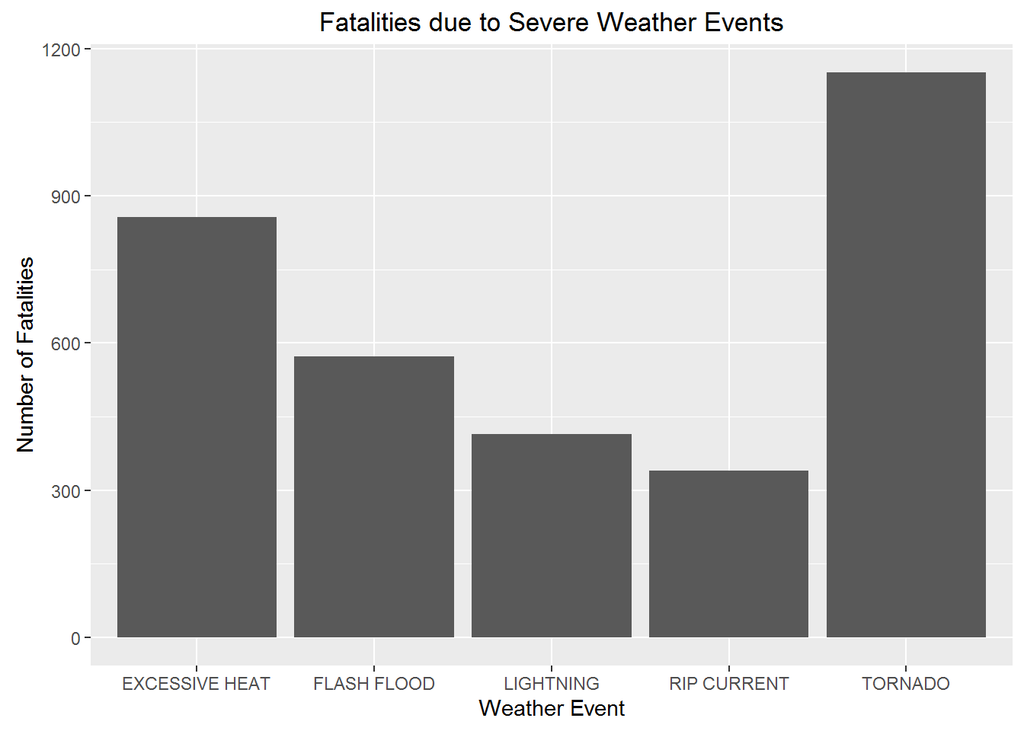

```r
ggplot(casualties[1:5,], aes(x = factor(EVTYPE), y = fatalities)) +
  geom_bar(stat = "identity") +
  guides(fill = FALSE) + xlab("Weather Event") + ylab("Number of Fatalities") +
  ggtitle("Fatalities due to Severe Weather Events")
```

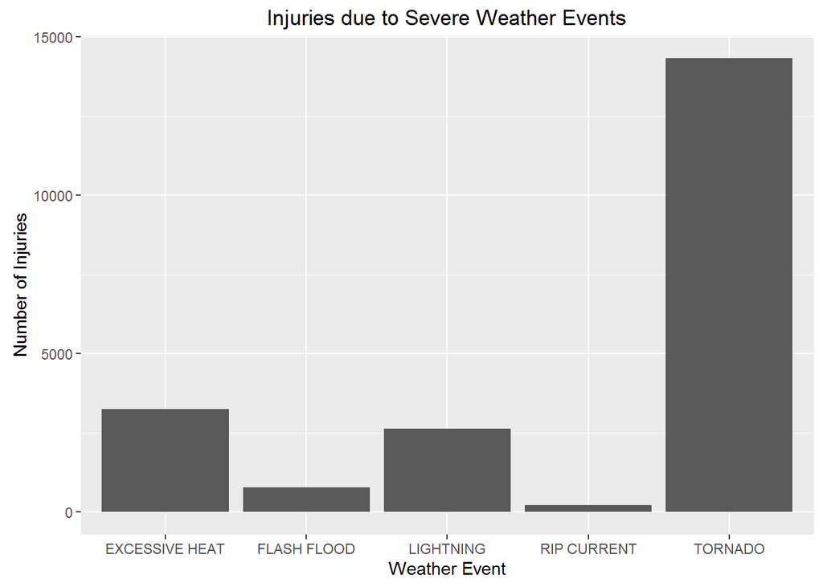

```r
ggplot(casualties[1:5,], aes(x = factor(EVTYPE), y = injuries)) +
  geom_bar(stat = "identity") +
  guides(fill = FALSE) + xlab("Weather Event") + ylab("Number of Injuries") +
  ggtitle("Injuries due to Severe Weather Events")
```

### Q2: Which weather events involve the greatest economic consequences?

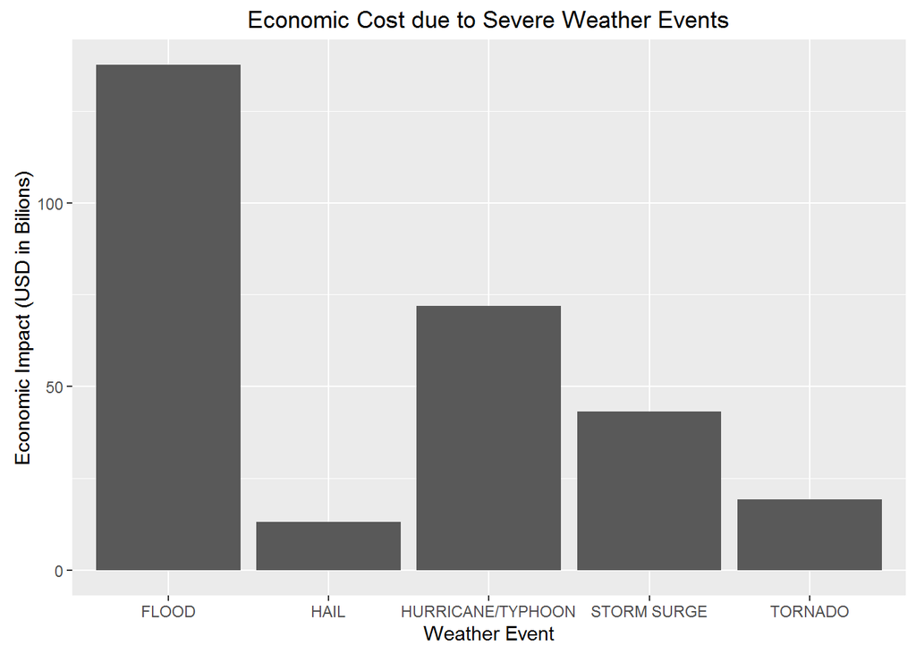

```r
required.data$PROPDMG.B <- recode(as.character(required.data$PROPDMGEXP), "'K'=1e-6; 'M'=1e-3;'B'=1;''=0")
required.data$PROPDMG.B <- required.data$PROPDMG.B * required.data$PROPDMG
required.data$CROPDMG.B <- recode(as.character(required.data$CROPDMGEXP), "'K'=1e-6; 'M'=1e-3;'B'=1;''=0")
required.data$CROPDMG.B <- required.data$CROPDMG.B * required.data$CROPDMG

event.cost <- group_by(required.data, EVTYPE) %>%
  summarize(property.dmg = sum(PROPDMG.B), crop.dmg = sum(CROPDMG.B))

event.cost.sub <- mutate(event.cost, total = property.dmg + crop.dmg) %>%
  arrange(desc(total))

ggplot(event.cost.sub[1:5,], aes(x = factor(EVTYPE), y = total)) +
  geom_bar(stat = "identity") +
  guides(fill = FALSE) + xlab("Weather Event") + ylab("Economic Impact (USD in Bilions)") +
  ggtitle("Economic Cost due to Severe Weather Events")
```